# Ch 4 Homework

**(b) Use the full data set to perform a logistic regression with `Directions` as the response and the five lag variables plus `Volume` as predictors. Use the summary function to print the results. Do any of the predictors appear to be statistically significant? If so, which ones?**

```r
glm.fit <- glm(Direction~Lag1+Lag2+Lag3+Lag4+Lag5+Volume, data=Weekly, family = binomial)
summary(glm.fit)
```

```
##
## Call:
## glm(formula = Direction ~ Lag1 + Lag2 + Lag3 + Lag4 + Lag5 +
##     Volume, family = binomial, data = Weekly)
##
## Deviance Residuals:
##     Min       1Q   Median       3Q      Max
## -1.6949  -1.2565   0.9913   1.0849   1.4579
##
## Coefficients:
##             Estimate Std. Error z value Pr(>|z|)
## (Intercept)  0.26686    0.08593   3.106   0.0019 **
## Lag1        -0.04127    0.02641  -1.563   0.1181
## Lag2         0.05844    0.02686   2.175   0.0296 *
## Lag3        -0.01606    0.02666  -0.602   0.5469
## Lag4        -0.02779    0.02646  -1.050   0.2937
## Lag5        -0.01447    0.02638  -0.549   0.5833
## Volume      -0.02274    0.03690  -0.616   0.5377
## ---
## Signif. codes:  0 '***' 0.001 '**' 0.01 '*' 0.05 '.' 0.1 ' ' 1
##
## (Dispersion parameter for binomial family taken to be 1)
##
##     Null deviance: 1496.2  on 1088  degrees of freedom
## Residual deviance: 1486.4  on 1082  degrees of freedom
## AIC: 1500.4
##
## Number of Fisher Scoring iterations: 4
```

Lag2 is statistically significant with a p-value of $< 0.05$.

**(c) Compute the confusion matrix and overall fraction of correct predictions. Explain what the confusion matrix is telling you about the types of mistakes made by logistic regression.**

```r
glm.probs <- predict(glm.fit, type='response')
glm.probs[1:10]
```

```
##         1         2         3         4         5         6         7         8
## 0.6086249 0.6010314 0.5875699 0.4816416 0.6169013 0.5684190 0.5786097 0.5151972
##         9        10
## 0.5715200 0.5554287
```

```r
#glm.probs
contrasts(Direction)
```

```
##      Up
## Down  0
## Up    1
```

```r
glm.pred <- rep("Down", 1089)
glm.pred[glm.probs > 0.5]="Up"
table(glm.pred, Direction)
```

```
##         Direction
## glm.pred Down  Up
##     Down   54  48
##     Up    430 557
```

There were 54 observations of `Down` predicted correctly and 557 observations of `Up` predicted correctly. This gives us a 56.11% accuracy. $\frac{54+557} {54+48+430+557} = 0.5611$

**(d) Now fit the logistic regression model using a training data period from 1990 to 2008, with `Lag2` as the only predictor. Compute the confusion matrix and the overall fraction of correct predictions for the held out data (that is, the data from 2009 and 2010).**

```r
training <- (Year <= 2008)
Weekly.08 <- Weekly[!training,]
Weekly.fit <- glm(Direction ~ Lag2, data = Weekly, subset = training, family = "binomial")
weekly.probs <- predict(Weekly.fit, Weekly.08, type = "response")
weekly.pred <- rep("Down", length(weekly.probs))
weekly.pred[weekly.probs > 0.5]="Up"
Direction.08 <- Direction[!training]
table(weekly.pred, Direction.08)
```

```
##            Direction.08
## weekly.pred Down Up
##        Down    9  5
##        Up     34 56
```

```r
mean(weekly.pred == Direction.08)
```

```
## [1] 0.625
```

**(e) Repeat (d) using LDA.**

```r
lda.fit <- lda(Direction ~ Lag2, data = Weekly, subset = training, family = "binomial")
lda.pred <- predict(lda.fit, Weekly.08)
lda.class <- lda.pred$class
table(lda.class, Direction.08)
```

```
##          Direction.08
## lda.class Down Up
##      Down    9  5
##      Up     34 56
```

```r
mean(lda.class==Direction.08)
```

```
## [1] 0.625
```

Using LDA, we also get a success rate of 62.5%.

**(f) Repeat (d) using QDA.**

```r
qda.fit <- qda(Direction ~ Lag2, data = Weekly, subset = training)
qda.fit
```

```
## Call:
## qda(Direction ~ Lag2, data = Weekly, subset = training)
##
## Prior probabilities of groups:
##      Down        Up
## 0.4477157 0.5522843
##
## Group means:
##             Lag2
## Down -0.03568254
## Up    0.26036581
```

```r
qda.class <- predict(qda.fit, Weekly.08)$class
table (qda.class, Direction.08)
```

```
##          Direction.08
## qda.class Down Up
##      Down    0  0
##      Up     43 61
```

```r
mean(qda.class==Direction.08)
```

```
## [1] 0.5865385
```

With QDA, our accuracy drops down to 58.65%.

**(g) Repeat (d) using KNN with K = 1.**

```r
weekly.training <- as.matrix(Lag2[training])
weekly.test <- as.matrix(Lag2[!training])
train.Direction <- Direction[training]


set.seed(1)
knn.pred <- knn(weekly.training, weekly.test, train.Direction, k=1)
table(knn.pred, Direction.08)
```

```
##         Direction.08
## knn.pred Down Up
##     Down   21 30
##     Up     22 31
```

```r
mean(knn.pred == Direction.08)
```

```
## [1] 0.5
```

Using KNN where $K = 1$, we get an accuracy of 50%.

**(h) Which of these methods appears to provide the best results on this data?**

The best methods are Logistic Regression and Linear Discriminant Analysis; both have an accuracy of 62.5%

**(i) Experiment with different combinations of predictors, including possible transformations and interactions, for each of the methods. Report the variables, method, and associated confusion matrix that appears to provide the best results on the held out data. Note that you should also experiment with values for K in the KNN classifier.**

### QDA

```r
qda.fit2 <- qda(Direction ~ Lag1 + Lag2 + Lag5, data = Weekly, subset = training)
qda.fit2
```

```
## Call:
## qda(Direction ~ Lag1 + Lag2 + Lag5, data = Weekly, subset = training)
##
## Prior probabilities of groups:
##      Down        Up
## 0.4477157 0.5522843
##
## Group means:
##              Lag1        Lag2       Lag5
## Down  0.289444444 -0.03568254 0.21409297
## Up   -0.009213235  0.26036581 0.04548897
```

```r
qda.class2 <- predict(qda.fit2, Weekly.08)$class
table (qda.class2, Direction.08)
```

```
##           Direction.08
## qda.class2 Down Up
##       Down    6 17
##       Up     37 44
```

```r
mean(qda.class2==Direction.08)
```

```
## [1] 0.4807692
```

### LDA

```r
lda.fit2 <- lda(Direction ~ Lag1 + Lag2 + Lag5, data = Weekly, subset = training, family = "binomial")
lda.pred2 <- predict(lda.fit2, Weekly.08)
lda.class2 <- lda.pred2$class
table(lda.class2, Direction.08)
```

```
##           Direction.08
## lda.class2 Down Up
##       Down    8 11
##       Up     35 50
```

```r
mean(lda.class2==Direction.08)
```

```
## [1] 0.5576923
```

```r
weekly.training2 <- cbind(Lag1, Lag2, Lag5)[training,]
weekly.test2 <- cbind(Lag1, Lag2, Lag5)[!training,]
train.Direction2 <- Direction[training]
set.seed(1)

knn.pred1 <- knn(weekly.training2, weekly.test2, train.Direction2, k=10)
table(knn.pred1, Direction.08)
```

```
##          Direction.08
## knn.pred1 Down Up
##      Down   18 21
##      Up     25 40
```

```r
mean(knn.pred1 == Direction.08)
```

```
## [1] 0.5576923
```

### 10NN

```r
knn.pred2 <- knn(weekly.training2, weekly.test2, train.Direction2, k=10)
table(knn.pred2, Direction.08)
```

```
##          Direction.08
## knn.pred2 Down Up
##      Down   18 23
##      Up     25 38
```

```r
mean(knn.pred2 == Direction.08)
```

```
## [1] 0.5384615
```

### 100NN

```r
knn.pred3 <- knn(weekly.training2, weekly.test2, train.Direction2, k=100)
table(knn.pred3, Direction.08)
```

```
##          Direction.08
## knn.pred3 Down Up
##      Down   15 22
##      Up     28 39
```

```r
mean(knn.pred3 == Direction.08)
```

```
## [1] 0.5192308
```

## Problem 11

In this problem, you will develop a model to predict whether a given car gets high or low gas mileage based on the [Auto](https://rdrr.io/cran/ISLR/man/Auto.html) data set.

```r
attach(Auto)
```

**(a) Create a binary variable, `mpg01`, that contains a 1 if `mpg` contains a value above its median, and a 0 if `mpg` contains a value below its median. You can compute the median using the `median()` function. Note you may find it helpful to use the `data.frame()` function to create a single data set containing both `mpg01` and the other `Auto` variables.**

```r
mpg01 <- rep(0, length(Auto$mpg))
mpg01[Auto$mpg > median(Auto$mpg)] <- 1
Auto <-  data.frame(Auto, mpg01)
```

**(b) Explore the data graphically in order to investigate the association between `mpg01` and the other features. Which of the other features seem most likely to be useful in predicting `mpg01`? Scatterplots and boxplots may be useful tools to answer this question. Describe your findings.**

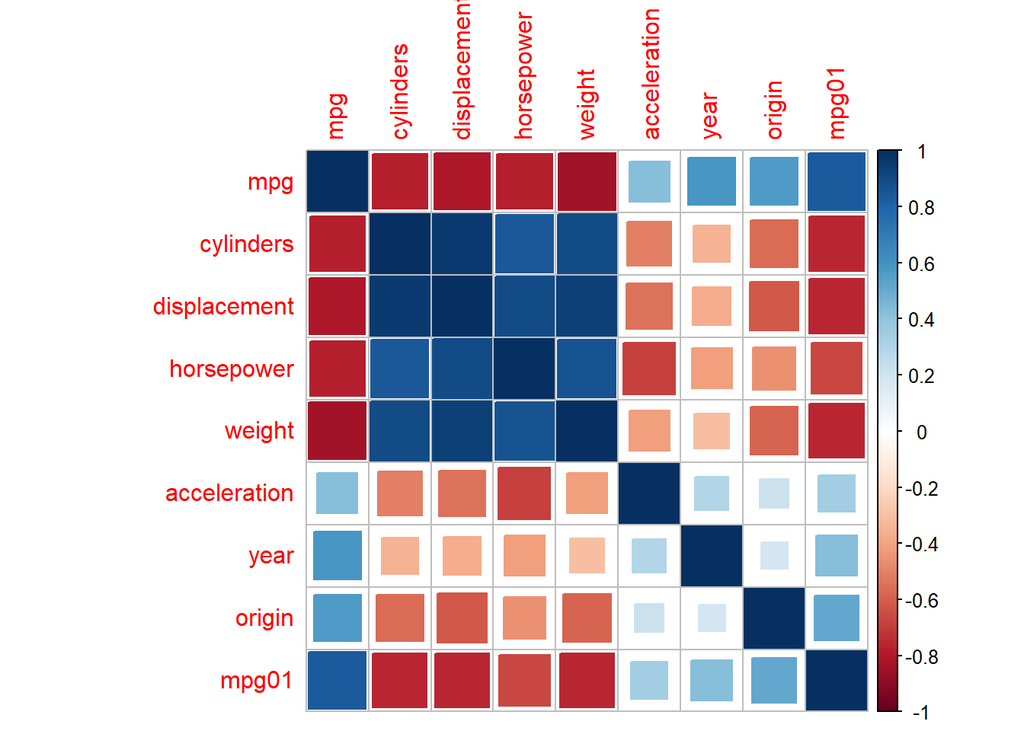

```r
corrplot(cor(Auto[,-9]), method = "square")
```

`Cylinders`, `Displacement`, and `Weight` have the strongest association with mpg01.There is also a strong association with `year`, as newer cars have better fuel efficiency.

**(c) Split the data into a training set and a test set.**

```r
set.seed(1234)
num_train <- nrow(Auto) * 0.7
in_Train <- sample(nrow(Auto), size = num_train)
Auto_training <- Auto[in_Train, ]
Auto_testing <- Auto[-in_Train, ]
```

**(d) Perform LDA on the training data in order to predict `mpg01` using the variables that seemed most associated with `mpg01` in (b). What is the test error of the model obtained?**

```r
Auto.lda <- lda(mpg01 ~ displacement + weight + cylinders + year, data = Auto_training)
Auto.prediction <- predict(Auto.lda, Auto_testing)
table(Auto.prediction$class, Auto_testing$mpg01)
```

```
##
##      0  1
##   0 49  1
##   1 15 53
```

```r
mean(Auto.prediction$class == Auto_testing$mpg01)
```

```
## [1] 0.8644068
```

This model has an error rate of 13.6%.

**(e) Perform QDA on the training data in order to predict `mpg01` using the variables that seemed most associated with `mpg01` in (b). What is the test error of the model obtained?**

```r
Auto.qda <- qda(mpg01 ~ displacement + weight + cylinders + year, data = Auto_training)
test.prediction <- predict(Auto.qda, Auto_testing)
table(test.prediction$class, Auto_testing$mpg01)
```

```
##
##      0  1
##   0 52  5
##   1 12 49
```

```r
mean(test.prediction$class == Auto_testing$mpg01)
```

```
## [1] 0.8559322
```

The QDA model has an accuracy of 85.6%, or an error rate of 14.4%.

**(f) Perform logistic regression on the training data in order to predict `mpg01` using only the variables that seemed most associated with mpg01 in (b). What is the test error of the model obtained?**

```r
Auto.logreg <- glm(mpg01 ~ displacement + weight + cylinders + year, data = Auto_training, family = "binomial")
predicted.probs <- predict(Auto.logreg, Auto_testing, type = "response")
preds <- rep(0, dim(Auto_testing)[1])
preds[predicted.probs > 0.5] = 1
table(preds, Auto_testing$mpg01)
```

```
##
## preds  0  1
##     0 54  4
##     1 10 50
```

```r
mean(preds == Auto_testing$mpg01)
```

```
## [1] 0.8813559
```

Logistic Regression has an accuracy of 88.1% or an error rate of 11.9%.

**(g) Perform KNN on the training data, with several values of K, in order to predict mpg01. Use only the variables that seemed most associated with `mpg01` in (b). What test errors do you obtain? Which value of K seems to perform the best on this data set?**

```r
train.x2 <- cbind(Auto_training$displacement, Auto_training$weight, Auto_training$cylinders, Auto_training$year)
test.x2 <- cbind(Auto_testing$displacement, Auto_testing$weight, Auto_testing$cylinders, Auto_testing$year)
train.y2 <- cbind(Auto_training$mpg01)
```

### For K = 1:

```r
knn.auto1 <- knn(train.x2, test.x2, train.y2, k=1 )
table(knn.auto1, Auto_testing$mpg01)
```

```
##
## knn.auto1  0  1
##         0 52  6
##         1 12 48
```

```r
mean(knn.auto1 == Auto_testing$mpg01)
```

```
## [1] 0.8474576
```

The accuracy of this model is 84.7%, or an error rate of 15.3%.

### For K = 10

```r
knn.auto10 <- knn(train.x2, test.x2, train.y2, k=10)
table(knn.auto10, Auto_testing$mpg01)
```

```
##
## knn.auto10  0  1
##          0 56  5
##          1  8 49
```

```r
mean(knn.auto10 == Auto_testing$mpg01)
```

```
## [1] 0.8898305
```

### For K = 20

```r
knn.auto20 <- knn(train.x2, test.x2, train.y2, k=20)
table(knn.auto20, Auto_testing$mpg01)
```

```
##
## knn.auto20  0  1
##          0 54  8
##          1 10 46
```

```r
mean(knn.auto20 == Auto_testing$mpg01)
```

```
## [1] 0.8474576
```

## Problem 13

**Using the [Boston](http://lib.stat.cmu.edu/datasets/boston) data set, fit classification models in order to predict whether a given suburb has a crime rate above or below the median. Explore logistic regression, LDA, and KNN models using various subset of the predictors. Describe your findings.**

```r
attach(Boston)
crim01 <- rep(0, length(crim))
crim01[crim > median(crim)] <- 1
Boston <- data.frame(Boston, crim01)

train.b <- 1:(length(crim)/2)
test.b <- (length(crim)/2+1): length(crim)
Boston.train <- Boston[train.b,]
Boston.test <- Boston[test.b,]
crim01.test <- crim01[test.b]
```

### Logistic Regression

```r
glm.fit.b <- glm(crim01 ~ . - crim01 - crim, data = Boston, family = binomial, subset = train.b)
summary(glm.fit.b)
```

```
##
## Call:
## glm(formula = crim01 ~ . - crim01 - crim, family = binomial,
##     data = Boston, subset = train.b)
##
## Deviance Residuals:
##      Min        1Q    Median        3Q       Max
## -2.83229  -0.06593   0.00000   0.06181   2.61513
##
## Coefficients:
##               Estimate Std. Error z value Pr(>|z|)
## (Intercept) -91.319906  19.490273  -4.685 2.79e-06 ***
## zn           -0.815573   0.193373  -4.218 2.47e-05 ***
## indus         0.354172   0.173862   2.037  0.04164 *
## chas          0.167396   0.991922   0.169  0.86599
## nox          93.706326  21.202008   4.420 9.88e-06 ***
## rm           -4.719108   1.788765  -2.638  0.00833 **
## age           0.048634   0.024199   2.010  0.04446 *
## dis           4.301493   0.979996   4.389 1.14e-05 ***
## rad           3.039983   0.719592   4.225 2.39e-05 ***
## tax          -0.006546   0.007855  -0.833  0.40461
## ptratio       1.430877   0.359572   3.979 6.91e-05 ***
## black        -0.017552   0.006734  -2.606  0.00915 **
## lstat         0.190439   0.086722   2.196  0.02809 *
## medv          0.598533   0.185514   3.226  0.00125 **
## ---
## Signif. codes:  0 '***' 0.001 '**' 0.01 '*' 0.05 '.' 0.1 ' ' 1
##
## (Dispersion parameter for binomial family taken to be 1)
##
##     Null deviance: 329.367  on 252  degrees of freedom
## Residual deviance:  69.568  on 239  degrees of freedom
## AIC: 97.568
##
## Number of Fisher Scoring iterations: 10
```

```r
glm.probs.b=predict(glm.fit.b, Boston.test, type = "response")
glm.pred.b <- rep(0, length(glm.probs.b))
glm.pred.b[glm.probs.b > 0.5] <- 1
table(glm.pred.b, crim01.test)
```

```
##           crim01.test
## glm.pred.b   0   1
##          0  68  24
##          1  22 139
```

```r
mean(glm.pred.b != crim01.test)
```

```
## [1] 0.1818182
```

For this logistic regression, there is an error rate of about 18.1%.

### LDA

```r
lda.fit.b <- lda(crim01 ~ . - crim01 - crim, data = Boston, subset = train.b)
lda.pred.b <- predict(lda.fit.b, Boston.test)
table(lda.pred.b$class, crim01.test)
```

```
##    crim01.test
##       0   1
##   0  80  24
##   1  10 139
```

```r
mean(lda.pred.b$class != crim01.test)
```

```
## [1] 0.1343874
```

For this LDA, the error rate is about 13.4%.

### KNN $(k = 1)$

```r
train.x.b <- cbind(zn, indus, chas, nox, rm, age, dis, rad, tax, ptratio, black, lstat, medv)[train.b,]
test.x.b <- cbind(zn, indus, chas, nox, rm, age, dis, rad, tax, ptratio, black, lstat, medv)[test.b,]
train.crim01 <- crim01[train.b]
set.seed(1)
knn.pred.b1 <- knn(train.x.b, test.x.b, train.crim01, k =1)
table(knn.pred.b1, crim01.test)
```

```
##            crim01.test
## knn.pred.b1   0   1
##           0  85 111
##           1   5  52
```

```r
mean(knn.pred.b1 != crim01.test)
```

```
## [1] 0.458498
```

For KNN $(k = 1)$, we have an error rate of 45.9%.

### KNN $(k = 10)$

```r
knn.pred.b10 <- knn(train.x.b, test.x.b, train.crim01, k = 10)
table(knn.pred.b10, crim01.test)
```

```
##             crim01.test
## knn.pred.b10   0   1
##            0  83  23
##            1   7 140
```

```r
mean(knn.pred.b10 != crim01.test)
```

```
## [1] 0.1185771
```

For KNN $(k = 10)$, our error rate decreases to 11.9%.

### KNN $(k = 20)$

```r
knn.pred.b20 <- knn(train.x.b, test.x.b, train.crim01, k = 20)
table(knn.pred.b20, crim01.test)
```

```
##             crim01.test
## knn.pred.b20   0   1
##            0  83  23
##            1   7 140
```

```r
mean(knn.pred.b20 != crim01.test)
```

```
## [1] 0.1185771
```

For KNN $(k = 20)$, our error rate remains at 11.9%.